# Lab 2 Text Data

```
Cameron Matson
Zihao Mao
```

## Purpose

This dataset is a collection reviews from Pitchfork, a music review site. It 18,393 reviews contains reviews from 1999 to the present day.

There is a lot of research being done related to the way that people interact with music, specifically how they describe it in words. What we'd like to get out of this data is if there is any relation between way the music is described in the reviews and the music itself. There's also interesting work to be done in sentiment analysis, what is what the emotion contained in a text is. One of the crudest forms of this is just whether that emotion is positive or negative.

The data was acquired at https://www.kaggle.com/nolanbconaway/pitchfork-data

## Data

### Aggregation and Cleaning

The data was stored in a database in several tables, so first we need to restructure it.

```python
import pandas as pd
import numpy as np

reviews = pd.read_csv('../data/reviews.csv')
print('number of reviews:',len(reviews))
reviews.head()
```

```
number of reviews: 18393
```

|  | reviewid | content |
| --- | --- | --- |
| 0 | 22703 | “Trip-hop” eventually became a ’90s punchline,... |
| 1 | 22721 | Eight years, five albums, and two EPs in, the ... |
| 2 | 22659 | Minneapolis’ Uranium Club seem to revel in bei... |
| 3 | 22661 | Kleenex began with a crash. It transpired one ... |
| 4 | 22725 | It is impossible to consider a given release b... |

```python
meta = pd.read_csv('../data/meta.csv')
meta.info()
meta.head()
```

```
<class 'pandas.core.frame.DataFrame'>
RangeIndex: 18393 entries, 0 to 18392
Data columns (total 13 columns):
reviewid          18393 non-null int64
title             18391 non-null object
artist            18391 non-null object
url               18393 non-null object
score             18393 non-null float64
best_new_music    18393 non-null int64
author            18393 non-null object
author_type       14487 non-null object
pub_date          18393 non-null object
pub_weekday       18393 non-null int64
pub_day           18393 non-null int64
pub_month         18393 non-null int64
pub_year          18393 non-null int64
dtypes: float64(1), int64(6), object(6)
memory usage: 1.8+ MB
```

|  | reviewid | title | artist | url | score | best_new_music | author | author_type | pub_date | pub_weekday | pub_day | pub_month | pub_year |
| --- | --- | --- | --- | --- | --- | --- | --- | --- | --- | --- | --- | --- | --- |
| 0 | 22703 | mezzanine | massive attack | http://pitchfork.com/reviews/albums/22703-mezz... | 9.3 | 0 | nate patrin | contributor | 2017-01-08 | 6 | 8 | 1 | 2017 |
| 1 | 22721 | prelapsarian | krallice | http://pitchfork.com/reviews/albums/22721-prel... | 7.9 | 0 | zoe camp | contributor | 2017-01-07 | 5 | 7 | 1 | 2017 |
| 2 | 22659 | all of them naturals | uranium club | http://pitchfork.com/reviews/albums/22659-all-... | 7.3 | 0 | david glickman | contributor | 2017-01-07 | 5 | 7 | 1 | 2017 |
| 3 | 22661 | first songs | kleenex, liliput | http://pitchfork.com/reviews/albums/22661-firs... | 9.0 | 1 | jenn pelly | associate reviews editor | 2017-01-06 | 4 | 6 | 1 | 2017 |
| 4 | 22725 | new start | taso | http://pitchfork.com/reviews/albums/22725-new-... | 8.1 | 0 | kevin lozano | tracks coordinator | 2017-01-06 | 4 | 6 | 1 | 2017 |

All we want from the meta data is the score and best_new_music feature, because we want to see if we can label the reviewers feelings about the album from the text itself.

```python
meta.drop(['title','artist', 'url', 'author', 'author_type', 'best_new_music', 'pub_date', 'pub_weekday', 'pub_day', 'pub_month', 'pub_year'], axis=1, inplace=True)
meta.info()
meta.head()
```

```
<class 'pandas.core.frame.DataFrame'>
RangeIndex: 18393 entries, 0 to 18392
Data columns (total 2 columns):
reviewid    18393 non-null int64
score       18393 non-null float64
dtypes: float64(1), int64(1)
memory usage: 287.5 KB
```

|  | reviewid | score |
| --- | --- | --- |
| 0 | 22703 | 9.3 |
| 1 | 22721 | 7.9 |
| 2 | 22659 | 7.3 |
| 3 | 22661 | 9.0 |
| 4 | 22725 | 8.1 |

Finally we want the genre to see if we can infer that from the review

```python
genres = pd.read_csv('../data/genres.csv')

# some have multiple genres, for now lets just choose the first one
genres.drop_duplicates(subset=['reviewid'],inplace=True)

genres.info()
genres.head()
```

```
<class 'pandas.core.frame.DataFrame'>
Int64Index: 18389 entries, 0 to 22679
Data columns (total 2 columns):
reviewid    18389 non-null int64
genre       16024 non-null object
dtypes: int64(1), object(1)
memory usage: 431.0+ KB
```

|  | reviewid | genre |
| --- | --- | --- |
| 0 | 22703 | electronic |
| 1 | 22721 | metal |
| 2 | 22659 | rock |
| 3 | 22661 | rock |
| 4 | 22725 | electronic |

It appears that some of the reviews didn't have genres listed. We'll drop these.

```python
genres.dropna(inplace=True)
genres.info()
```

```
<class 'pandas.core.frame.DataFrame'>
Int64Index: 16024 entries, 0 to 22676
Data columns (total 2 columns):
reviewid    16024 non-null int64
genre       16024 non-null object
dtypes: int64(1), object(1)
memory usage: 375.6+ KB
```

```python
df = pd.merge(genres, reviews, on='reviewid')
df = pd.merge(df, meta, on='reviewid')
df.info()
df.head()
```

```
<class 'pandas.core.frame.DataFrame'>
Int64Index: 16030 entries, 0 to 16029
Data columns (total 4 columns):
reviewid    16030 non-null int64
genre       16030 non-null object
content     16021 non-null object
score       16030 non-null float64
dtypes: float64(1), int64(1), object(2)
memory usage: 626.2+ KB
```

|  | reviewid | genre | content | score |
| --- | --- | --- | --- | --- |
| 0 | 22703 | electronic | “Trip-hop” eventually became a ’90s punchline,... | 9.3 |
| 1 | 22721 | metal | Eight years, five albums, and two EPs in, the ... | 7.9 |
| 2 | 22659 | rock | Minneapolis’ Uranium Club seem to revel in bei... | 7.3 |
| 3 | 22661 | rock | Kleenex began with a crash. It transpired one ... | 9.0 |
| 4 | 22725 | electronic | It is impossible to consider a given release b... | 8.1 |

Looks like there were still a few reviews that didn't match up in all three tables, or that there were some null values in which if fine, we'll just drop to the lowest common denominator

```python
df.dropna(inplace=True)
df.info()
```

```
<class 'pandas.core.frame.DataFrame'>
Int64Index: 16021 entries, 0 to 16029
Data columns (total 4 columns):
reviewid    16021 non-null int64
genre       16021 non-null object
content     16021 non-null object
score       16021 non-null float64
dtypes: float64(1), int64(1), object(2)
memory usage: 625.8+ KB
```

That's a lot of reviews, for efficiency's sake lets just take a sample

```python
df_sample = df.sample(n=5000).dropna()
df_sample.reset_index(inplace=True)
df_sample.info()
```

```
<class 'pandas.core.frame.DataFrame'>
RangeIndex: 5000 entries, 0 to 4999
Data columns (total 5 columns):
index       5000 non-null int64
reviewid    5000 non-null int64
genre       5000 non-null object
content     5000 non-null object
score       5000 non-null float64
dtypes: float64(1), int64(2), object(2)
memory usage: 195.4+ KB
```

## Feature Representation

### Bag of Words

```python
from sklearn.feature_extraction.text import CountVectorizer

# make a CountVectorizer object
counter = CountVectorizer(stop_words='english')

# list where each element is an entire review
all_text = df_sample.content.tolist()

# use counter object to transorm the text in to BOW
bag_words = counter.fit_transform(all_text)
print(bag_words.shape)
```

```
(5000, 71296)
```

```python
# I'm not even going to run this cell, because it takes too long
# print(counter.vocabulary_)
```

That's a lot of words. How might we be able to reduce it? The problem is that the most common way that people talk about music is through metaphor, so it makes it difficult to choose a narrow vocabulary in general. However, for this analysis, we are primarilly concerned with how the reviewer *described* the album, therefore we might limit our vocabulary to words that describe things i.e. adjectives and adverbs.

To do this we'll use a Parts of Speech Tagger from the Natrual Language Toolkit. We will be using a unigram tagger, which assigns the most common tag to a word, based on a corpus. We do this because our bag of words model has already stripped the potential part of speech context provided by the sentence.

```python
def make_descriptor_vocab(old_vocab):
    '''Returns a list of adjectives and adverbs found in (list) old_vocab'''
    vocab = []

    # Unigram Tagger is an object that is trained on an already tagged dataset, in this case the Brown Corpus.
    # https://en.wikipedia.org/wiki/Brown_Corpus
    unigram_tagger = UnigramTagger(brown.tagged_sents())


    for tok, tag in unigram_tagger.tag(old_vocab):
        # words unknown to the tagger are taged None, JJ and RB corespond to adj. and adv. respectively
        if tag is not None and (tag[0:2] == 'JJ' or tag[0:2] == 'RB'):
            vocab.append(tok)

    return vocab
```

```python
from nltk.tag import UnigramTagger
from nltk.corpus import brown
```

```python
%%time

vocab = make_descriptor_vocab([w for w in counter.vocabulary_.keys()]) # pass in the list of words in the old vocab
```

```
Wall time: 7.03 s
```

```python
print(len(vocab))
```

```
4820
```

Hey! That seems managable!

```python
counter = CountVectorizer(stop_words='english', vocabulary=vocab)

bag_words = counter.fit_transform(all_text)

df_bow = pd.DataFrame(data=bag_words.toarray(), columns=counter.get_feature_names())

print(df_bow.shape)
df_bow.head()
```

```
(5000, 4820)
```

|  | nice | slow | steadily | strikingly | afraid | sure | maybe | giant | slowly | good | ... | inapplicable | penurious | oversize | parasympathetic | inconveniently | absentmindedly | recurrently | unopened | penal | nondiscriminatory |
| --- | --- | --- | --- | --- | --- | --- | --- | --- | --- | --- | --- | --- | --- | --- | --- | --- | --- | --- | --- | --- | --- |
| 0 | 1 | 1 | 1 | 1 | 1 | 2 | 1 | 1 | 1 | 2 | ... | 0 | 0 | 0 | 0 | 0 | 0 | 0 | 0 | 0 | 0 |
| 1 | 0 | 0 | 0 | 0 | 0 | 0 | 1 | 0 | 0 | 0 | ... | 0 | 0 | 0 | 0 | 0 | 0 | 0 | 0 | 0 | 0 |
| 2 | 0 | 0 | 0 | 0 | 1 | 1 | 0 | 0 | 0 | 0 | ... | 0 | 0 | 0 | 0 | 0 | 0 | 0 | 0 | 0 | 0 |
| 3 | 0 | 0 | 0 | 0 | 0 | 0 | 1 | 0 | 0 | 1 | ... | 0 | 0 | 0 | 0 | 0 | 0 | 0 | 0 | 0 | 0 |
| 4 | 0 | 0 | 0 | 0 | 0 | 0 | 0 | 0 | 0 | 0 | ... | 0 | 0 | 0 | 0 | 0 | 0 | 0 | 0 | 0 | 0 |

5 rows × 4820 columns

The words that have the highest frequency in the corpus are:

```python
df_bow.agg('sum', axis=0).sort_values(ascending=False)[:10]
```

```
just      7064
new       5563
best      3509
good      3084
long      2712
really    2039
old       1953
hard      1916
early     1874
better    1820
dtype: int64
```

Those really don't seem too descriptive, or rather descriptive in the sense of conveying information about the genre, or the valence of the reviewers emotion.

### TF-IDF

A more compmlex representation of the dataset would be term frequency, inverse document frequency or TFIDF which takes into consideration not only how frequently a word appears in each document (tf), but also how frequently it appears in the corpus as a whole (idf). Again we'll limit the model to descriptors (adj. and adv.)

```python
from sklearn.feature_extraction.text import TfidfVectorizer

# TFIDF object
tfidfer = TfidfVectorizer(stop_words='english', vocabulary=vocab)


tfidf = tfidfer.fit_transform(all_text)
print(tfidf.shape)

df_tfidf = pd.DataFrame(data=tfidf.toarray(),columns=tfidfer.get_feature_names())
df_tfidf.head()
```

```
(5000, 4820)
```

|  | nice | slow | steadily | strikingly | afraid | sure | maybe | giant | slowly | good | ... | inapplicable | penurious | oversize | parasympathetic | inconveniently | absentmindedly | recurrently | unopened | penal | nondiscriminatory |
| --- | --- | --- | --- | --- | --- | --- | --- | --- | --- | --- | --- | --- | --- | --- | --- | --- | --- | --- | --- | --- | --- |
| 0 | 0.116403 | 0.093843 | 0.175942 | 0.190776 | 0.159413 | 0.199230 | 0.094701 | 0.170563 | 0.124551 | 0.133593 | ... | 0.0 | 0.0 | 0.0 | 0.0 | 0.0 | 0.0 | 0.0 | 0.0 | 0.0 | 0.0 |
| 1 | 0.000000 | 0.000000 | 0.000000 | 0.000000 | 0.000000 | 0.000000 | 0.074301 | 0.000000 | 0.000000 | 0.000000 | ... | 0.0 | 0.0 | 0.0 | 0.0 | 0.0 | 0.0 | 0.0 | 0.0 | 0.0 | 0.0 |
| 2 | 0.000000 | 0.000000 | 0.000000 | 0.000000 | 0.113201 | 0.070738 | 0.000000 | 0.000000 | 0.000000 | 0.000000 | ... | 0.0 | 0.0 | 0.0 | 0.0 | 0.0 | 0.0 | 0.0 | 0.0 | 0.0 | 0.0 |
| 3 | 0.000000 | 0.000000 | 0.000000 | 0.000000 | 0.000000 | 0.000000 | 0.068113 | 0.000000 | 0.000000 | 0.048043 | ... | 0.0 | 0.0 | 0.0 | 0.0 | 0.0 | 0.0 | 0.0 | 0.0 | 0.0 | 0.0 |
| 4 | 0.000000 | 0.000000 | 0.000000 | 0.000000 | 0.000000 | 0.000000 | 0.000000 | 0.000000 | 0.000000 | 0.000000 | ... | 0.0 | 0.0 | 0.0 | 0.0 | 0.0 | 0.0 | 0.0 | 0.0 | 0.0 | 0.0 |

5 rows × 4820 columns

Let's look to see which words had the highest TFIDF for the corpus as a whole. To do this we'll take the mean of the tfidf values for each word over all of the documents

```python
# 10 highest tfidf terms
df_tfidf.agg('mean', axis=0).sort_values(ascending=False)[:10]
```

```
just      0.050728
new       0.044418
best      0.032602
good      0.031897
long      0.028200
really    0.023900
black     0.023887
old       0.023289
hard      0.022655
early     0.022325
dtype: float64
```

So this is essentially the same list as before with a few new ones, but for the large part, still not very descriptive. Maybe when we group them by class we'll get something more useful. In the mean time, let's look at the distribution of TFIDF scores over the corpus.

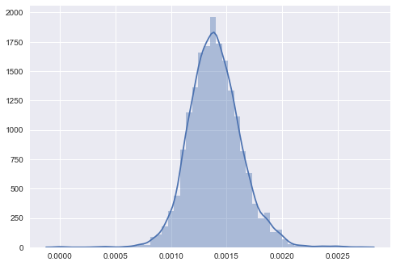

```python
import seaborn as sns
import matplotlib.pyplot as plt
sns.distplot(df_tfidf.agg('mean', axis=1))
plt.show()
```

Looks nice and gaussian. Moving on!

## Summary Statistics

```python
import matplotlib.pyplot as plt
import seaborn as sns
%matplotlib inline

import plotly as py
import plotly.graph_objs as go
py.offline.init_notebook_mode() # run at the start of every ipython notebook
```

### Word Frequencies

```python
df_vocab = df_bow.agg('sum',axis = 0).sort_values(ascending = False)[:10]

df_trace = go.Bar(
    x = df_vocab.keys(),
    y = df_vocab.values,
    text = df_vocab.keys(),
    name = 'vocab'
)


data = [df_trace]
layout = go.Layout(
    barmode='group',
    title='Most Frequent Words',
    xaxis={'title':'word rank'},
    yaxis={'title':'Frequency', 'type':'log'}
)

fig = go.Figure(data=data, layout=layout)
py.offline.iplot(fig, filename='most_frequent')
```

[interactive chart not shown]

```
    As we can see from the graph above, the most of the most frequently used words in the dataset are adjectives like "new", "best", etc. It's reasonable that reviewer used them to describe their feeling about the albums. Interestingly, for some reasons, they really like to use the word "just".
```

### Document Length

First we need to add a feature corresponding to the length of the review

```python
df_sample['length'] = df.content.str.len()
# occasionaly (because of sampling, there are some empty reviews)
df_sample.dropna(inplace=True)
df_sample.head()
```

|  | index | reviewid | genre | content | score | length |
| --- | --- | --- | --- | --- | --- | --- |
| 0 | 13159 | 1233 | rock | It's so nice to hear Joey Burns realizing that... | 7.5 | 9310.0 |
| 1 | 610 | 21985 | rock | The Avett Brothers once seemed to hold an infi... | 3.8 | 2797.0 |
| 2 | 15589 | 1286 | rock | Not long after its official origins in the ear... | 7.4 | 3565.0 |
| 3 | 4788 | 16272 | rock | Denton, Texas, punk mainstay Mark Ryan (Marked... | 7.7 | 7717.0 |
| 4 | 15763 | 5226 | rock | Though it appears that somebody made an error ... | 6.8 | 3210.0 |

Let's look at the distribution of review lengths.

```python
df_sample.info()
```

```
<class 'pandas.core.frame.DataFrame'>
Int64Index: 4997 entries, 0 to 4999
Data columns (total 6 columns):
index       4997 non-null int64
reviewid    4997 non-null int64
genre       4997 non-null object
content     4997 non-null object
score       4997 non-null float64
length      4997 non-null float64
dtypes: float64(2), int64(2), object(2)
memory usage: 273.3+ KB
```

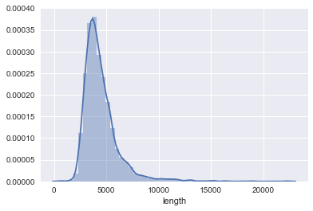

```python
sns.distplot(df_sample.length)
```

### most relevant words

```python
df_relevance = df_tfidf.agg('mean', axis=0).sort_values(ascending=False)[:10]

df_trace = go.Bar(
    x = df_relevance.keys(),
    y = df_relevance.values,
    text = df_relevance.keys(),
    name = 'vocab',
    marker=dict(
        color='rgb(34,139,34)',
    )
)

data = [df_trace]
layout = go.Layout(
    barmode='group',
    title='Most Relevant Words',
    xaxis={'title':'word rank'},
    yaxis={'title':'TF.IDF', 'type':'log'}
)

fig = go.Figure(data=data, layout=layout)
py.offline.iplot(fig, filename='most_relevant')
```

[interactive chart not shown]

```
    The same trend of the words are also shown in the words with the highest TF.IDF values. It was very obvious that there is a great similarity between the most frequent words and the most relevant words. It's interesting to say "just" is the most frequent and relevant word used in the music review.
```

## Relation to Target Class

What we want to do is look at how the text relates to the following labels:

- genre
- reviewer emotion (score/best_new_music)

### Genre

We'd like to see if we could classify the genre of an album from the way that it was reviewed. Pitchfork categorizes albums from the following categories.

```python
set(df_sample.genre)
```

```
{'electronic',
 'experimental',
 'folk/country',
 'global',
 'jazz',
 'metal',
 'pop/r&b',
 'rap',
 'rock'}
```

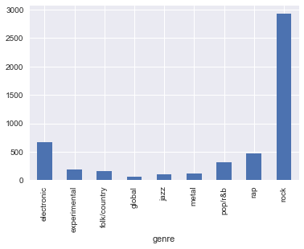

```python
df_sample.groupby(by='genre').size().plot(kind='bar') # note that this not the sampled DataFrame from above
plt.show()
```

Clearly rock is the most reviewed genre. This makes sense as Pitchfork started out as a site for exclusively for Indie music reviews, and I wouldn't be suprised to see if most of those reviews were labeled 'rock'. Let's look at 2 differnet genres (rock and rap)

```python
rock = df_sample[df_sample.genre == 'rock']
rap = df_sample[df_sample.genre=='rap']
```

#### Word Frequency

Let's make a bag of words model for each of genres to see if there are any noticeable differences between them.

```python
def make_bow(data, descriptor_only=False):
    '''Creates a Bag of Words Dataframe from the list <data>.  If <descriptor_only> is true \
it will remove all words that aren't adjectives adverbs'''
    counter = CountVectorizer(stop_words='english')

    words = counter.fit_transform(data)

    if descriptor_only:
        vocab = make_descriptor_vocab([w for w in counter.vocabulary_.keys()])

        counter = CountVectorizer(stop_words='english', vocabulary=vocab)

        words = counter.fit_transform(data)

    df_bow = pd.DataFrame(data=words.toarray(), columns=counter.get_feature_names())
    return df_bow
```

```python
%%time
rock_bow = make_bow(rock.content.tolist(), True)
rap_bow = make_bow(rap.content.tolist(), True)
```

```
Wall time: 17.5 s
```

```python
print('Rock reviews had a vocabulary of {} words'.format(rock_bow.shape[1]))
print('Rap reviews had a vocabulary of {} words'.format(rap_bow.shape[1]))
```

```
Rock reviews had a vocabulary of 4499 words
Rap reviews had a vocabulary of 3063 words
```

Lets look at the overlap and difference

```python
# words and their freq for genre as a whole
rock_vocab = rock_bow.agg('sum', axis=0)
rap_vocab = rap_bow.agg('sum', axis=0)

# words that appear in both genres
intersection = set.intersection(set(rock_vocab.keys()), set(rap_vocab.keys()))

# words that only appear in each genre
rock_only = set(rock_vocab.keys()) - intersection
rap_only = set(rap_vocab.keys()) - intersection

pd.DataFrame([len(rock_only), len(rap_only), len(intersection)], index=['rock', 'rap', 'both'], columns=['unique vocab size'])
```

|  | unique vocab size |
| --- | --- |
| rock | 1532 |
| rap | 96 |
| both | 2967 |

This result implies that the way people the reviewers describe each of these genres is similar.

```python
# top ten of each category
rock_top = rock_vocab[rock_only].sort_values(ascending=False)[:10]
rap_top = rap_vocab[rap_only].sort_values(ascending=False)[:10]
general_top = rock_vocab[intersection].sort_values(ascending=False)[:10] # since the intersection is
                                                                            # both we just pull from one series
```

```python
rock_trace = go.Bar(
    x=list(range(1,len(rock_top)+1)),
    y=rock_top.values,
    text=rock_top.keys(),
    name='rock'

)

rap_trace = go.Bar(
    x=list(range(1,len(rap_top)+1)),
    y=rap_top.values,
    text=rap_top.keys(),
    name='rap'
)

both_trace = go.Bar(
    x=list(range(1,len(general_top)+1)),
    y=general_top.values,
    text=general_top.keys(),
    name='both'
)

data = [rock_trace, rap_trace, both_trace]
layout = go.Layout(
    barmode='group',
    title='Most Frequent Words',
    xaxis={'title':'word rank'},
    yaxis={'title':'Frequency', 'type':'log'}
)

fig = go.Figure(data=data, layout=layout)
py.offline.iplot(fig, filename='most_frequent')
```

[interactive chart not shown]

We can interpret two things from the above chart:

1. The most common words used in both genres appear *way* more often than words used specifically in one genre
2. The words specific to one genre are more descriptive, and have stronger connotations. For example, (in one running of the notebook*) look at the third most frequent word in each of the groups
   - both: best
   - rock: fluffy
   - rap: **murderous**

Both of these points make sense, as words that are less descriptive and more general can be used to describe, in general, more things. However, its hard to say whether the words that only appear in rock reviews are inheirently more *rock* than the words that appear only in rap reviews, or vice versa.

*since reviews are randomly sampled each time this will change from run to run, but its included because it illustrates the point well.

#### "Relevant" Words

Let's look at which words are "relevant" to each category according to they're TFIDF rank. We'll be performing the same analysis as before, but grouped by genre.

First we'll group pick out the tfidf values for each class

```python
rock_tfidf = df_tfidf.iloc[rock.index]
rap_tfidf = df_tfidf.iloc[rap.index]
```

And look at how the values are distributed over the words.

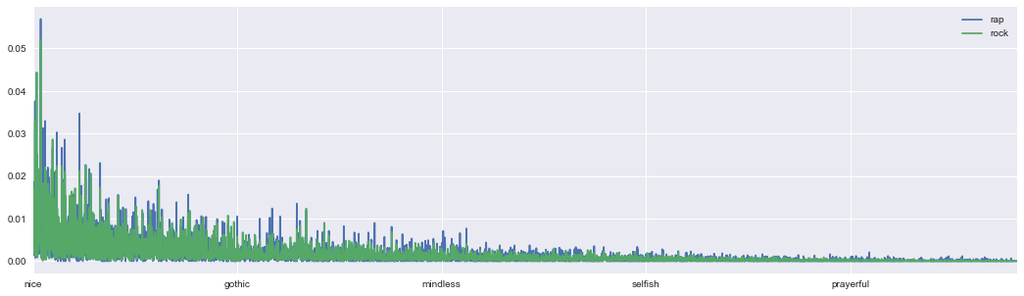

```python
plt.figure(figsize=(18,5))
rap_tfidf.agg('mean', axis=0).plot()
rock_tfidf.agg('mean', axis=0).plot()
plt.legend(['rap', 'rock'])

plt.show()
```

There doesn't seem to be much distinction between the tfidf for rap and rock.

Let's at words that only appear in either rap or rock (i.e. are not in the intersection.

```python
rock_tfidf_top = rock_tfidf.agg('mean', axis=0).sort_values(ascending=False)[:100]
rap_tfidf_top = rap_tfidf.agg('mean', axis=0).sort_values(ascending=False)[:100]

rock_only_words = set(rock_tfidf_top.keys()) - set(rap_tfidf_top.keys())
rap_only_words = set(rap_tfidf_top.keys()) - set(rock_tfidf_top.keys())

rock_tfidf_top = rock_tfidf_top[rock_only_words].sort_values(ascending=False)
rap_tfidf_top = rap_tfidf_top[rap_only_words].sort_values(ascending=False)
```

```python
rock_trace = go.Bar(
    x=list(range(1,len(rock_tfidf_top)+1)),
    y=rock_tfidf_top.values,
    text=rock_tfidf_top.keys(),
    name='rock'

)
rap_trace = go.Bar(
    x=list(range(1,len(rap_tfidf_top)+1)),
    y=rap_tfidf_top.values,
    text=rap_tfidf_top.keys(),
    name='rap'

)

data = [rock_trace, rap_trace]
layout = go.Layout(
    barmode='group',
    title='Most Relevant Words',
    xaxis={'title':'word rank'},
    yaxis={'title':'TFIDF',}
)

fig = go.Figure(data=data, layout=layout)
py.offline.iplot(fig, filename='most_frequent')
```

[interactive chart not shown]

This looks a little better, as the words themselves have more meaning and connotation. So if we were to try to classify as 'rock' or 'rap' we could jsut look for these wors but again, because the total distributions were nearly identical, its probably not a very good tool.

### Rating

Perhaps if we group by a different a label, namely the score that the review recieved. In theory this should be a more defining feature, as english has a well defined set of words with positive and negative connotations.

First let's take a look at the score distributions.

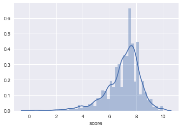

```python
sns.distplot(df_sample.score)
plt.show()
```

Looks pretty top heavy with a relatively wide peak, which is expected--no one wants to read a site that just says every album is bad, but they also want a little variety.

Let's just see how it breaks down by genre.

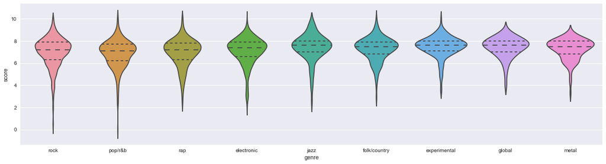

```python
plt.figure(figsize=(20,5))
sns.violinplot(x='genre', y='score', data=df_sample, inner='quartile')
plt.show()
```

They appear to all have relatively the same distribution, with a median score around 7. This means that we shouldn't have to worry about the genre biasing the score.

Lets discretize the score column into three bins: bad, neutral, and good.

```python
df_sample['feeling'] = pd.cut(df_sample.score, 3, labels=['bad', 'eh', 'good'])

df_sample.head()
```

|  | index | reviewid | genre | content | score | length | feeling |
| --- | --- | --- | --- | --- | --- | --- | --- |
| 0 | 13159 | 1233 | rock | It's so nice to hear Joey Burns realizing that... | 7.5 | 9310.0 | good |
| 1 | 610 | 21985 | rock | The Avett Brothers once seemed to hold an infi... | 3.8 | 2797.0 | eh |
| 2 | 15589 | 1286 | rock | Not long after its official origins in the ear... | 7.4 | 3565.0 | good |
| 3 | 4788 | 16272 | rock | Denton, Texas, punk mainstay Mark Ryan (Marked... | 7.7 | 7717.0 | good |
| 4 | 15763 | 5226 | rock | Though it appears that somebody made an error ... | 6.8 | 3210.0 | good |

```python
# let's give them their own dfs
bad = df_sample[df_sample.feeling=='bad']
eh = df_sample[df_sample.feeling=='eh']
good = df_sample[df_sample.feeling=='good']
```

Again let's look at the distribution of these categories

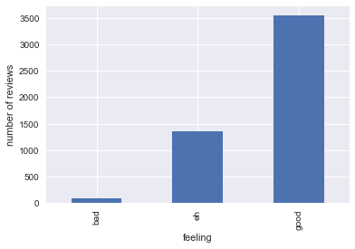

```python
df_sample.groupby('feeling').size().plot.bar()
plt.ylabel('number of reviews')
plt.show()
```

So the sizes of the groups are pretty disparate, however, since we're only looking within each group for word frequency and relevancy it shouldn't matter.

#### Frequency

Now we'll go throught the same Bag-of-Words and TFIDF modeling as before.

```python
%%time
bad_bow = make_bow(bad.content, True)
eh_bow = make_bow(eh.content, True)
good_bow = make_bow(good.content, True)
```

```
Wall time: 25 s
```

```python
# words and their freq for each category
bad_vocab = bad_bow.agg('sum', axis=0)
eh_vocab = eh_bow.agg('sum', axis=0)
good_vocab = good_bow.agg('sum', axis=0)

# words that appear in all categories
intersection = set.intersection(set(bad_vocab.keys()), set(eh_vocab.keys()), set(good_vocab.keys()))

# words that only appear in each category
bad_only = set(bad_vocab.keys()) - intersection
eh_only = set(eh_vocab.keys()) - intersection
good_only = set(good_vocab.keys()) - intersection
```

```python
# grab top ten words in each category
bad_top = bad_vocab[rock_only].sort_values(ascending=False)[:10]
eh_top = eh_vocab[rap_only].sort_values(ascending=False)[:10]
good_top = good_vocab[rap_only].sort_values(ascending=False)[:10]
```

```python
bad_trace = go.Bar(
    x=list(range(1,len(bad_top)+1)),
    y=bad_top.values,
    text=bad_top.keys(),
    name='bad',
    marker={'color':'rgb(168, 21, 21)'}

)

eh_trace = go.Bar(
    x=list(range(1,len(eh_top)+1)),
    y=eh_top.values,
    text=eh_top.keys(),
    name='eh',
    marker={'color':'rgb(224, 226, 206)'}
)

good_trace = go.Bar(
    x=list(range(1,len(good_top)+1)),
    y=good_top.values,
    text=good_top.keys(),
    name='good',
    marker={'color':'rgb(14, 122, 34)'}
)

data = [bad_trace, eh_trace, good_trace]
layout = go.Layout(
    barmode='group',
    title='Most Frequent Words',
    xaxis={'title':'word rank'},
    yaxis={'title':'Frequency', 'type':'log'}
)

fig = go.Figure(data=data, layout=layout)
py.offline.iplot(fig, filename='most_frequent')
```

[interactive chart not shown]

#### Relevancy

Now we'll look at TFIDF as a measure of relevancy.

```python
bad_tfidf = df_tfidf.iloc[bad.index]
eh_tfidf = df_tfidf.iloc[eh.index]
good_tfidf = df_tfidf.iloc[good.index]
```

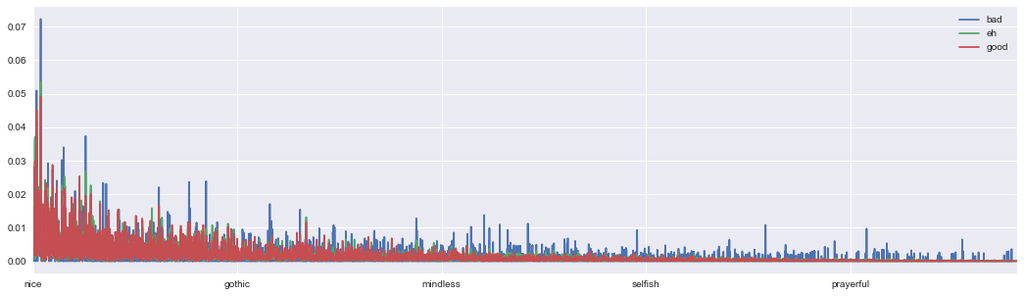

```python
plt.figure(figsize=(18,5))
bad_tfidf.agg('mean', axis=0).plot()
eh_tfidf.agg('mean', axis=0).plot()
good_tfidf.agg('mean', axis=0).plot()
plt.legend(['bad', 'eh', 'good'])

plt.show()
```

Again it looks like there is a lot of overlap between the three groups in terms of their TFIDF values. Let's go through the same process as before of looking at the words specific to each class.

```python
bad_tfidf_top = bad_tfidf.agg('mean', axis=0).sort_values(ascending=False)[:100]
eh_tfidf_top = eh_tfidf.agg('mean', axis=0).sort_values(ascending=False)[:100]
good_tfidf_top = good_tfidf.agg('mean', axis=0).sort_values(ascending=False)[:100]

bad_only_words = set(bad_tfidf_top.keys()) - set(eh_tfidf_top.keys()) - set(good_tfidf_top.keys())
good_only_words = set(good_tfidf_top.keys()) - set(eh_tfidf_top.keys()) - set(bad_tfidf_top.keys())

bad_tfidf_top = bad_tfidf_top[bad_only_words].sort_values(ascending=False)[:10]
good_tfidf_top = good_tfidf_top[good_only_words].sort_values(ascending=False)[:10]
```

```python
bad_trace = go.Bar(
    x=list(range(1,len(bad_tfidf_top)+1)),
    y=bad_tfidf_top.values,
    text=bad_tfidf_top.keys(),
    name='bad',
    marker={'color':'rgb(168, 21, 21)'}
)

good_trace = go.Bar(
    x=list(range(1,len(good_tfidf_top)+1)),
    y=good_tfidf_top.values,
    text=good_tfidf_top.keys(),
    name='good',
    marker={'color':'rgb(14, 122, 34)'}
)

data = [bad_trace, good_trace]
layout = go.Layout(
    barmode='group',
    title='Most Relevant Words',
    xaxis={'title':'word rank'},
    yaxis={'title':'Mean TFIDF',}
)

fig = go.Figure(data=data, layout=layout)
py.offline.iplot(fig, filename='most_frequent')
```

[interactive chart not shown]

This actually performs pretty well. Nearly all of the words that show up in exclusively the bad reviews are explicitly bad in connotation, the opposite for good reviews. So if we were to classify based reviews as good or bad, we might be able to scan for these words.

# Word Cloud

## The most frequent words

```python
from wordcloud import WordCloud, STOPWORDS
from PIL import Image
import os
```

```python
d = os.getcwd()
note_mask_1 = np.array(Image.open(os.path.join(d,"music_note_1.png")))
```

```python
df_freq_wordcloud = df_bow.agg('sum',axis = 0).sort_values(ascending = False)[:100]
text = ' '.join(df_freq_wordcloud.keys())
wordcloud = WordCloud(width = 1000, height = 400, relative_scaling = 1, stopwords = set(), background_color = "white",mask = note_mask_1).generate(text)
```

```
(-0.5, 443.5, 594.5, -0.5)
```

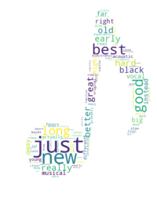

```python
plt.imshow(wordcloud,  interpolation = "bilinear")
plt.axis("off")
```

```
    The preceding word cloud lists the top 100 most frequently used adjectives and adverbs. The font size is associated with the rank of the word's frequency. Obviously the most frequntly used words are "just" and "new".
```

```python
note_mask_2 = np.array(Image.open(os.path.join(d,"music_note_2.jpg")))
df_rele_wordcloud = df_tfidf.agg('max', axis=0).sort_values(ascending=False)[:100]
text = ' '.join(df_freq_wordcloud.keys())
wordcloud = WordCloud(width = 1000, height = 400, relative_scaling = 1, stopwords = set(), background_color = "white",mask = note_mask_2).generate(text)
```

```
(-0.5, 625.5, 625.5, -0.5)
```

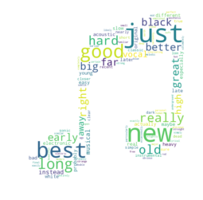

```python
plt.imshow(wordcloud, interpolation = "bilinear")
plt.axis("off")
```

[output not shown]

# Reference

[https://www.kaggle.com/nolanbconaway/pitchfork-data]